# Step 1. Converting data to hyperframes

The purpose of this vignette is letting users convert dataframes with spatiotemporal dimensions to hyperframes with point process data. By the end of this vignette, users will be able to convert data to a hyperframe.

The functions that are introduced in this vignette are as follows:

- `get_hfr`
- `vis_hfr`

# 1 Loading data

We will use two csv files: `activ.csv` and `airstr.csv`.

- `activ.csv`: spatiotemporal information of outcomes (i.e., insurgencies)
- `airstr.csv`: spatiotemporal information of treatment (i.e., airstrikes)

Let’s first check what these datasets look like.

## 1.1 Outcome data

```r
head(activ)
```

```
#> # A tibble: 6 × 4
#>   latitude longitude date       type_out
#>      <dbl>     <dbl> <date>     <chr>
#> 1     33.8      44.8 2007-02-23 SAF
#> 2     33.2      43.5 2007-02-23 IED
#> 3     33.4      43.3 2007-02-23 other_outcome
#> 4     33.3      44.0 2007-02-23 IED
#> 5     33.2      44.1 2007-02-23 SAF
#> 6     34.5      41.9 2007-02-23 SAF
```

It should be noted that location information is saved in the decimal degree format. If the original data is not in the decimal degree format, then it is recommended that you convert it to the decimal degree format.

There are three subtypes of insurgencies (column `type_out`):

- improvised explosive devices (IED),
- small arms fire (SAF), and
- other outcomes.

```r
table(activ$type_out)
```

```
#>
#>           IED other_outcome           SAF
#>         15601         37292         15680
```

## 1.2 Treatment data

```r
head(airstr)
```

```
#> # A tibble: 6 × 4
#>   latitude longitude date       Type
#>      <dbl>     <dbl> <date>     <chr>
#> 1     33.4      43.5 2007-02-23 Airstrike
#> 2     32.9      44.2 2007-02-23 SOF
#> 3     32.9      44.2 2007-02-23 SOF
#> 4     33.2      43.8 2007-02-24 Airstrike
#> 5     33.2      43.8 2007-02-24 Airstrike
#> 6     33.2      43.8 2007-02-24 Airstrike
```

There are two sub-categories of airstrikes:

- airstrikes and
- shows of force (SOF: simulated airstrikes where no weapons are released).

```r
table(airstr$Type)
```

```
#>
#> Airstrike       SOF
#>      2446      1492
```

# 2 Converting the data to hyperframes

Our first task is to convert data to a collection of point processes. Intuitively, we want to generate maps of all the locations of airstrikes and insurgencies for all subtypes and all dates. For dates and subtypes with no observations, we want to generate an empty map.

## 2.1 `get_hfr` function

The key function here is `get_hfr`. This function does the following:

1. aggregating all observations by dates and subtypes, and converting them to a point process;
2. identifying dates with zero observations and generating an empty map for those dates; and
3. sorting everything and creating a hyperframe.

Note that a hyperframe is just like a dataframe but each element can be anything, such as point processes and pixel images.

To use `get_hfr`, all you need to do is to specify the following arguments:

- `data`: the name of the dataframe that you want to pre-process;
- `subtype_column`: the name of the column that specifies subtypes (of treatment or outcome);
- `window`: an `owin` element (essentially, a map of your interest);
- `time_column`: the name of the column for time;
- `time_range`: the range of time periods of your interest;
- `coordinates`: the names of columns for longitudes and latitudes (in this order); and
- `combined`: an argument for generating a combined output.

If you set `combined = TRUE`, then this function also returns point processes for each date, with every subtype combined. This is useful if you are interested in mapping all treatment or outcomes as one map for each date.

## 2.2 Converting data to hyperframes

So let’s try it out. We first convert treatment data to a hyperframe.

```r
# Treatment
treatment_hfr <- get_hfr(data = airstr,
                         subtype_column = "Type",
                         window = iraq_window,
                         time_column = "date",
                         time_range = c("2007-02-23", "2008-07-05"),
                         coordinates = c("longitude", "latitude"),
                         combined = TRUE)
```

```
#> Converting the data to ppp objects...
#> Converting the data to a hyperframe...
#> Generating a hyperframe of point processes...
```

If you have multiple observations at the same time, then you will receive a warning message saying

```
data contain duplicated
points
```

. This is a generic message that an internal function generates. As long as the data truly contains multiple observations happening at the same time, you can ignore this warning message.

The output of this function is a hyperframe, with each element being a point process, denoted as `(ppp)` in the output.

```r
head(treatment_hfr)
```

```
#> Hyperframe:
#>         time Airstrike   SOF all_combined
#> 1 2007-02-23     (ppp) (ppp)        (ppp)
#> 2 2007-02-24     (ppp) (ppp)        (ppp)
#> 3 2007-02-25     (ppp) (ppp)        (ppp)
#> 4 2007-02-26     (ppp) (ppp)        (ppp)
#> 5 2007-02-27     (ppp) (ppp)        (ppp)
#> 6 2007-02-28     (ppp) (ppp)        (ppp)
```

Since we set `combined = TRUE`, we have a new column `all_combined`, which combines `Airstrike` and `SOF` and returns an aggregated point process.

## 2.3 Visualizing point processes

How does each ppp look like? One way to visualize this is to treat this hyperframe just like a dataframe and plot each observation. For example, if you are interested in airstrikes on February 24, 2007, then you can plot it as follows.

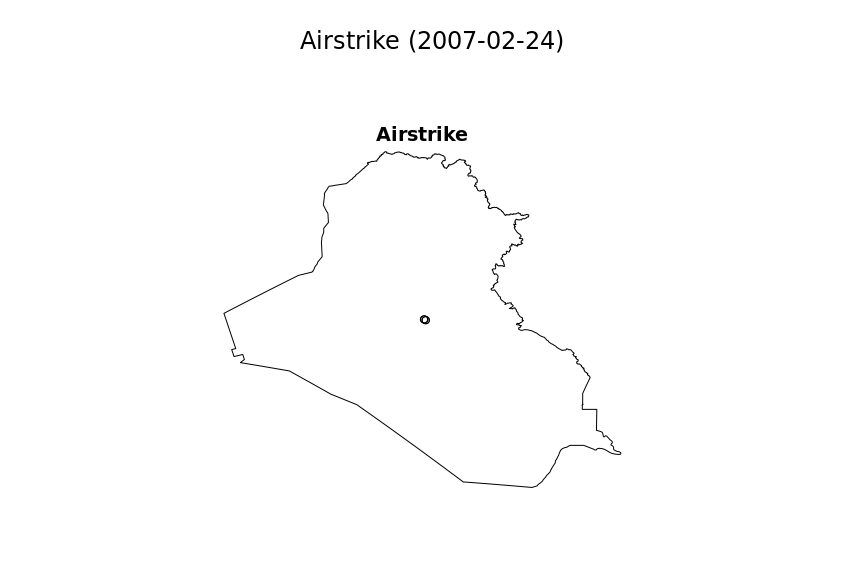

```r
plot(treatment_hfr[which(treatment_hfr$time == "2007-02-24"), "Airstrike"],
     main = "Airstrike (2007-02-24)")
```

In this plot, each circle represents the location of an airstrike, and the boundaries show the borders of Iraq (as defined by the window).

This looks fine, but you may be interested in plotting airstrikes over several days, either aggregating data over several days or visualizing them separately. In this case, `vis_hfr` function is useful.

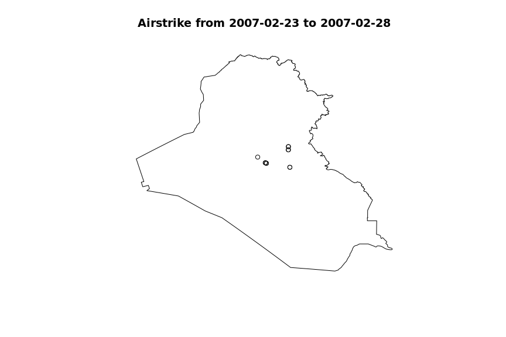

```
#> Symbol map with no parameters
```

```r
vis_hfr(hfr = treatment_hfr,
        subtype_column = "Airstrike",
        time_column = "time",
        range = c("2007-02-23", "2007-02-28"),
        combined = TRUE,
        marks = TRUE)
```

If you specify `marks = FALSE`, then each day is represented by different shapes.

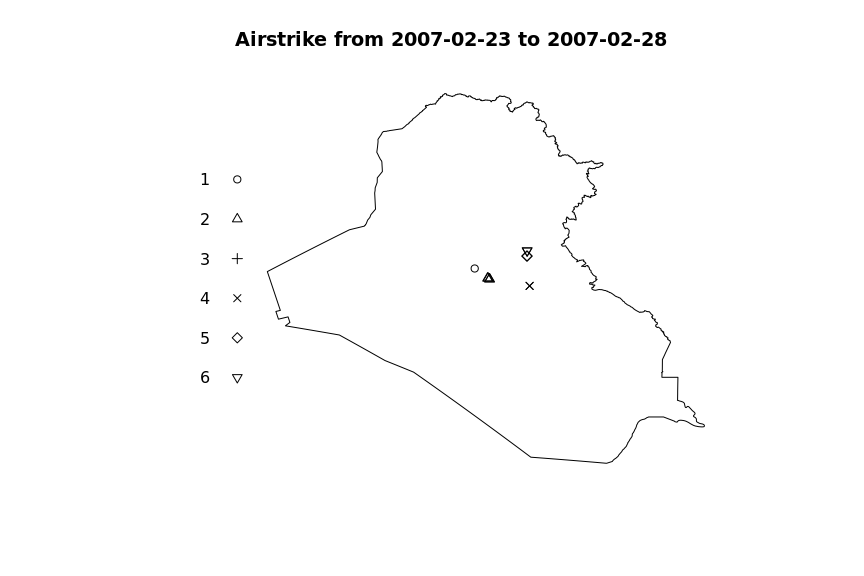

```
#> Symbol map for discrete inputs:
#> [1] "1" "2" "3" "4" "5" "6"
#> chars: [1] 1 2 3 4 5 6
```

```r
vis_hfr(hfr = treatment_hfr,
        subtype_column = "Airstrike",
        time_column = "time",
        range = c("2007-02-23", "2007-02-28"),
        combined = TRUE,
        marks = FALSE)
```

By setting `combined = FALSE`, you can also use this function to generate separate plots for each date.

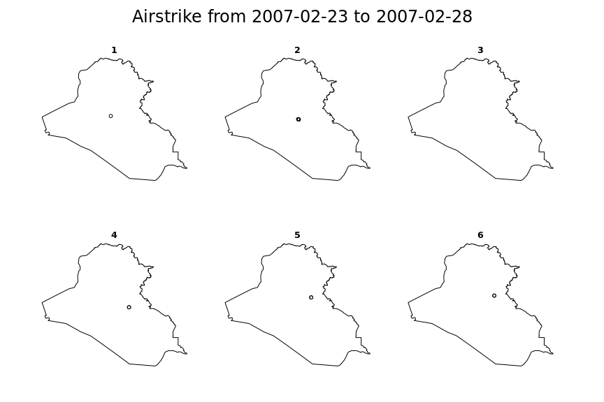

```r
vis_hfr(hfr = treatment_hfr,
        subtype_column = "Airstrike",
        time_column = "time",
        range = c("2007-02-23", "2007-02-28"),
        combined = FALSE)
```

## 2.4 Combining hyperframes

Now that we understand what hyperframes and point processes look like, we can continue to convert outcome data and combine the the two hyperframes. The output is a hyperframe with dates and point processes for both treatment and outcomes.

```r
# Outcome
outcome_hfr <- get_hfr(data = activ,
                       subtype_column = "type_out",
                       window = iraq_window,
                       time_column = "date",
                       time_range = c("2007-02-23", "2008-07-05"),
                       coordinates = c("longitude", "latitude"),
                       combined = TRUE)
```

```
#> Converting the data to ppp objects...
#> Converting the data to a hyperframe...
#> Generating a hyperframe of point processes...
```

```r
# Combine the two
dat_hfr <- spatstat.geom::cbind.hyperframe(treatment_hfr, outcome_hfr[, -1])
names(dat_hfr)[names(dat_hfr) == "all_combined"] <- "all_treatment"
names(dat_hfr)[names(dat_hfr) == "all_combined.1"] <- "all_outcome"

head(dat_hfr)
```

```
#> Hyperframe:
#>         time Airstrike   SOF all_treatment   SAF   IED other_outcome
#> 1 2007-02-23     (ppp) (ppp)         (ppp) (ppp) (ppp)         (ppp)
#> 2 2007-02-24     (ppp) (ppp)         (ppp) (ppp) (ppp)         (ppp)
#> 3 2007-02-25     (ppp) (ppp)         (ppp) (ppp) (ppp)         (ppp)
#> 4 2007-02-26     (ppp) (ppp)         (ppp) (ppp) (ppp)         (ppp)
#> 5 2007-02-27     (ppp) (ppp)         (ppp) (ppp) (ppp)         (ppp)
#> 6 2007-02-28     (ppp) (ppp)         (ppp) (ppp) (ppp)         (ppp)
#>   all_outcome
#> 1       (ppp)
#> 2       (ppp)
#> 3       (ppp)
#> 4       (ppp)
#> 5       (ppp)
#> 6       (ppp)
```